# Radians

# Radians

- In mathematics, the standard way to measure an angle is [radians](https://en.wikipedia.org/wiki/Radian).
  - Not degrees!

$$360^{\circ}~=~2\pi~\text{radians}$$
$$180^{\circ}~=~\pi~\text{radians}$$
$$1~\text{radian}
~\approx~57.3^{\circ}$$

- In radians, common angles are often expressed as a product (multiplication) of $\pi$ and a [rational number](https://en.wikipedia.org/wiki/Rational_number), or a fraction of $\pi$.

$$\begin{align}
30^{\circ}~&=~\frac{\pi}{6}~\text{radians} \\\\
45^{\circ}~&=~\frac{\pi}{4}~\text{radians} \\\\
60^{\circ}~&=~\frac{\pi}{3}~\text{radians} \\\\
90^{\circ}~&=~\frac{\pi}{2}~\text{radians} \\\\
120^{\circ}~&=~\frac{2\pi}{3}~\text{radians} \\\\
135^{\circ}~&=~\frac{3\pi}{4}~\text{radians} \\\\
150^{\circ}~&=~\frac{5\pi}{6}~\text{radians}
\end{align}$$

- *Technically, we do not even need to say “radians” as the unit. If an angle is expressed without an explicit unit, we assume the angle is in radians. This is because radians are a “[dimensionless](https://en.wikipedia.org/wiki/Dimensionless_quantity) ratio” of an arc length over a radius.*

# Convert from degrees to radians

- To convert from degrees to radians, use the fact that $180^{\circ}=\pi~\text{radians}$ to make a [conversion factor](https://en.wikipedia.org/wiki/Conversion_of_units#Factor%E2%80%93label_method).
- In other words, multiply by $\frac{\pi~\text{radians}}{180^{\circ}}$.
- Example, convert 42° to radians:
- $$42^{\circ}~=~\frac{42^{\circ}}{1}\cdot\frac{\pi~\text{rad}}{180^{\circ}}$$
- $$42^{\circ}~=~\frac{7\pi}{30}
  ~\text{rad}$$
- $$42^{\circ}~\approx~
  0.7330383~\text{rad}$$

# Convert from radians to degrees

- To convert from radians to degrees, multiply by $\frac{180^{\circ}}{\pi~\text{radians}}$.
- Example, convert $\frac{\pi}{9}$ radians to degrees:
- $$\frac{\pi}{9}\cdot
  \frac{180^{\circ}}{\pi} ~=~ 20^{\circ}$$

# Visual/geometric interpretation

- Draw a circle of radius $r$.
- Draw a central angle, $\theta$, in standard position.
- That central angle subtends an arc length $L$.

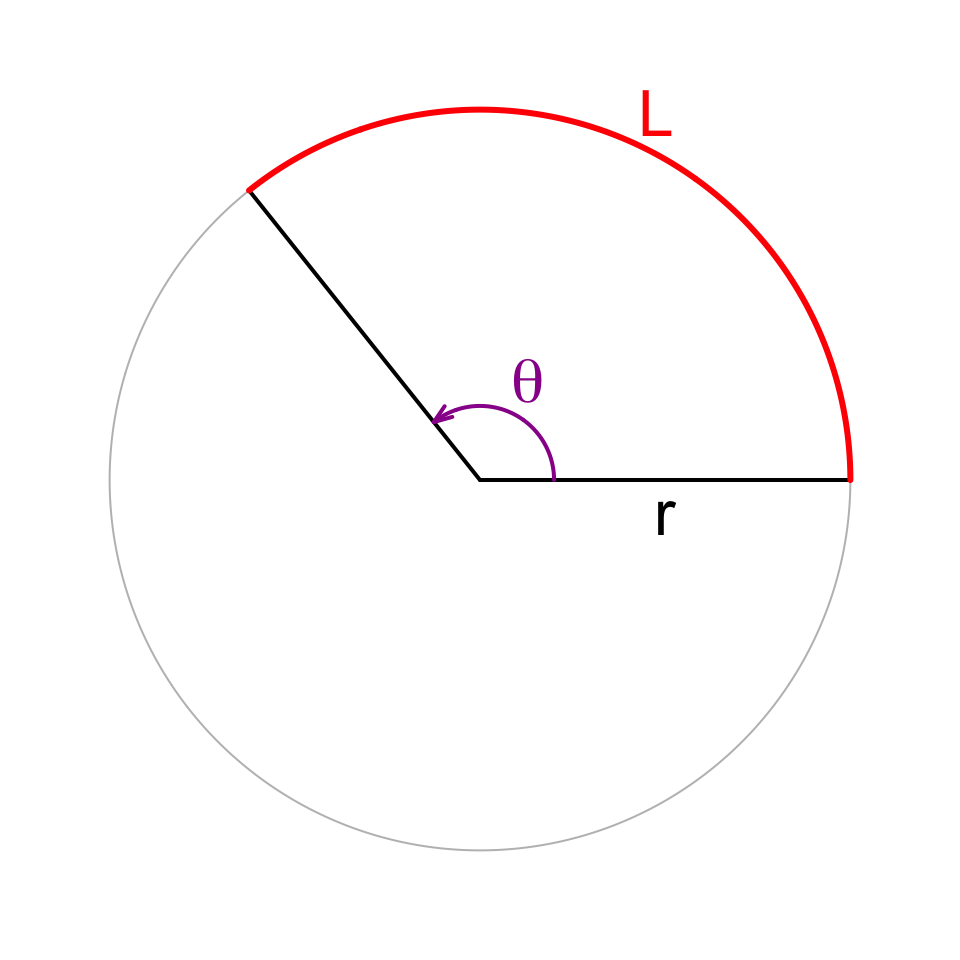

- In radians, there is a simple relationship between these three quantities.

$$\theta = \frac{L}{r}$$

- Notice, in degrees, this is more complicated…
  $$\theta = \frac{L\cdot
  180^{\circ}}{r\cdot\pi}$$

# Learning Objective F-TF.A.1

- F-TF.A.1: Understand radian measure of an angle as the length of the arc on the unit circle subtended by the angle.

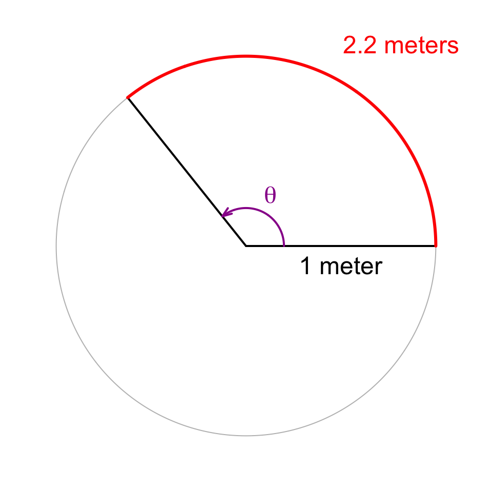

- What is the angle measure (in radians)?
- $\theta~=~2.2$ radians